# O cenário da cidade do Rio de Janeiro: rede de empresas

## Distribuição populacional da cidade do Rio de Janeiro

Primeiramente, conforme feito anteriormente:

- posicionamos as residências;
- distribuímos os indivíduos em suas residências; e
- posicionamos os indivíduos em torno de suas residências.

### Carregando os dados

Carregamos os dados populacionais por quilômetro quadrado da cidade do Rio de Janeiro obtidos do [Landscan](https://landscan.ornl.gov), mudando para 0 o valor das células com -1.

```python
landscan_rio = np.load('../input/landscan/landscan_rio.npy').astype(int)
landscan_rio = np.maximum(landscan_rio, 0)
```

### Visualização em escala logarítmica

Visualizamos

$$ ln( 1 + \textrm{população}) $$

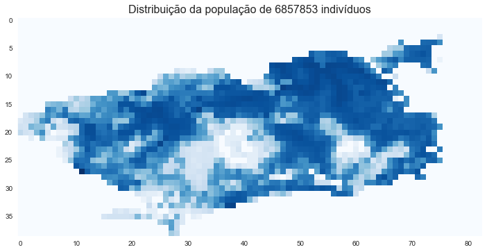

```python
plt.figure(figsize=(12,6))
plt.imshow(np.log(1 + landscan_rio), cmap='Blues', interpolation='nearest')
plt.grid(False)
plt.title(f'Distribuição da população de {int(landscan_rio.sum())} indivíduos', fontsize=16)
plt.show()
```

## Rede residencial

Montamos a rede residencial como antes.

O importante para a montagem da rede de empresas não é a rede residencial em si, apenas a localização dos indivíduos feita na construção da rede residencial.

### Reduzindo a população

Com o objetivo de realizar testes mais rápidos, com populações menores, dividimos a população de cada bloco por um determinado fator.

Essa divisão nos dá números em ponto flutuante, que então truncamos para a sua parte inteira.

```python
censo_residencial = np.array([.21, .26, .20, .17, .08, .04, .02, 0.02])
pop_por_blocos = (landscan_rio/100).astype(int)
```

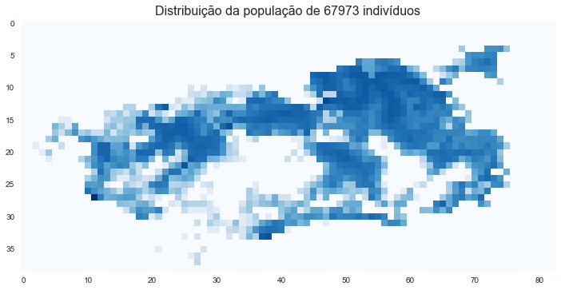

```python
plt.figure(figsize=(12,6))
plt.imshow(np.log(1 + pop_por_blocos), cmap='Blues', interpolation='nearest')
plt.grid(False)
plt.title(f'Distribuição da população de {pop_por_blocos.sum()} indivíduos', fontsize=16)
plt.show()
```

### Distribuindo e alocando os indivíduos e as suas residências

```python
%%time
pos_residencias, pos_individuos, res_individuos \
    = episiming.cenarios.aloca_residencias_e_individuos(pop_por_blocos, censo_residencial)
```

```
CPU times: user 1.01 s, sys: 206 ms, total: 1.21 s
Wall time: 1.35 s
```

### Gerando o grafo da rede residencial

```python
%%time
attrib_pos_individuos = {j: pos_individuos[j] for j in range(len(pos_individuos))}

G_r = nx.random_geometric_graph(len(pop_por_blocos), 0, pos=attrib_pos_individuos)

for individuos in res_individuos:
    if len(individuos) > 1:
        G_r.add_edges_from([(i,j) for i in individuos for j in individuos if i < j])
```

```
CPU times: user 365 ms, sys: 23.2 ms, total: 388 ms
Wall time: 388 ms
```

### Viualização

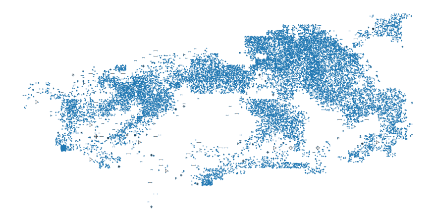

```
CPU times: user 1.64 s, sys: 33.8 ms, total: 1.68 s
Wall time: 1.68 s
```

```python
%%time
plt.figure(figsize=(12,6))
nx.draw(G_r, pos=attrib_pos_individuos, node_size=1, alpha=0.5)
plt.show()
```

## Rede empresarial

Na construção da rede empresarial, a ideia é fazer os seguintes passos:

- Distribuir o número de empresas por tamanho da empresa seguindo uma distribuição na forma de uma lei de potência próxima a de uma [lei de Zipf](https://en.wikipedia.org/wiki/Zipf%27s_law), com parâmetros escolhidos de acordo com a população total e um número máximo de tamanho (ou médio?).
- Distribuir as empresas pelos blocos, com pesos de acordo com a população de cada bloco.
- Alocar os indivíduos em cada empresa, levando em consideração uma determinada distância média de deslocamento.

### Distribuição das empresas por tamanho

#### Distribuição log-normal

Distribuição [log-normal](https://docs.scipy.org/doc/scipy/reference/generated/scipy.stats.lognorm.html)

```python
emp_tam_medio = 10
shape = 1
scale = np.exp(emp_tam_medio)
loc = 0

emp_tam = np.arange(1,1001)
emp_nind = stats.lognorm.pdf(emp_tam, shape, loc, scale)
```

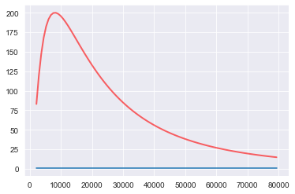

```python
x = np.linspace(stats.lognorm.ppf(0.01, shape, loc, scale),
                stats.lognorm.ppf(0.9, shape, loc, scale), 100)

plt.plot(x, 6700000*stats.lognorm.pdf(x, shape, loc, scale),
       'r-', lw=2, alpha=0.6, label='lognorm pdf')
plt.plot(x, np.ones_like(x))
plt.figure()
```